# Big data, Assignment 3 | Matic Zadobovšek, Matija Bažec

## Data

In this assignment we are working with data for Yellow taxis in New York, and we decided to get our data directly from the ARNES cluster, which is available at `/d/hpc/projects/FRI/bigdata/data/Taxi`.

First we did a simple inspection of the data available:

```
ls yellow_tripdata_*.parquet | head
```

Returned:

```
yellow_tripdata_2009-01.parquet
yellow_tripdata_2009-02.parquet
yellow_tripdata_2009-03.parquet
yellow_tripdata_2009-04.parquet
yellow_tripdata_2009-05.parquet
yellow_tripdata_2009-06.parquet
yellow_tripdata_2009-07.parquet
yellow_tripdata_2009-08.parquet
yellow_tripdata_2009-09.parquet
yellow_tripdata_2009-10.parquet
```

And also:

```
ls yellow_tripdata_*.parquet | tail
```

Returned:

```
yellow_tripdata_2024-04.parquet
yellow_tripdata_2024-05.parquet
yellow_tripdata_2024-06.parquet
yellow_tripdata_2024-07.parquet
yellow_tripdata_2024-08.parquet
yellow_tripdata_2024-09.parquet
yellow_tripdata_2024-10.parquet
yellow_tripdata_2024-11.parquet
yellow_tripdata_2024-12.parquet
yellow_tripdata_2025-01.parquet
```

Now we wanted to see the total count of files for yellow taxis:

```
ls yellow_tripdata_*.parquet | wc -l
```

And got:

```
193
```

Based on the previous outputs from **head** and **tail** commands, we can assume that we have data available from January 2009 to January 2025, but let's make sure by running this:

```
ls yellow_tripdata_*.parquet | cut -d'_' -f3 | cut -d'-' -f1 | sort | uniq
```

And we can see that we really have all needed information about the following years:

```
2009
2010
2011
2012
2013
2014
2015
2016
2017
2018
2019
2020
2021
2022
2023
2024
2025
```

One final check that we can do is to see the count of files for each year, so we can be sure that we really have information for all months in each year.

```
for y in $(ls yellow_tripdata_*.parquet | cut -d'_' -f3 | cut -d'-' -f1 | sort | uniq); do
    echo -n "$y "
    ls yellow_tripdata_${y}-*.parquet 2>/dev/null | wc -l
done
```

And the output proves that we have all needed information for each year, except for 2025 (only information for January).

```
2009 12
2010 12
2011 12
2012 12
2013 12
2014 12
2015 12
2016 12
2017 12
2018 12
2019 12
2020 12
2021 12
2022 12
2023 12
2024 12
2025 1
```

Another thing that is important for our data ingestion is the size of the data we are working with. Let's do a small check for the 2024 data.

```
du -sh yellow_tripdata_2024-*.parquet
```

And the output is:

```
48M     yellow_tripdata_2024-01.parquet
49M     yellow_tripdata_2024-02.parquet
58M     yellow_tripdata_2024-03.parquet
57M     yellow_tripdata_2024-04.parquet
60M     yellow_tripdata_2024-05.parquet
58M     yellow_tripdata_2024-06.parquet
50M     yellow_tripdata_2024-07.parquet
49M     yellow_tripdata_2024-08.parquet
59M     yellow_tripdata_2024-09.parquet
62M     yellow_tripdata_2024-10.parquet
58M     yellow_tripdata_2024-11.parquet
59M     yellow_tripdata_2024-12.parquet
```

## Data ingestion

All of the obtained outputs and scripts we used are available on the ARNES cluster in the `/d/hpc/projects/FRI/bigdata/students/mz1034/A3` directory.

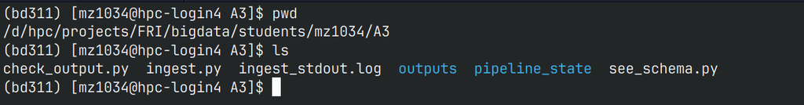

We decided to work on a subset of the data, and use the range of years from 2020-2024, because we only have data for January 2025 on the ARNES cluster.

First we inspected the 5 parquet files (one from each year) so we can see the structure of the data and the columns we have available, and try to detect any differences between them. Changes between the files are most likely to happen between separate years, so that is why we only checked January of each year. We used this small script, `see_schema.py`:

```
import pandas as pd

files = [
    "/d/hpc/projects/FRI/bigdata/data/Taxi/yellow_tripdata_2020-01.parquet",
    "/d/hpc/projects/FRI/bigdata/data/Taxi/yellow_tripdata_2021-01.parquet",
    "/d/hpc/projects/FRI/bigdata/data/Taxi/yellow_tripdata_2022-01.parquet",
    "/d/hpc/projects/FRI/bigdata/data/Taxi/yellow_tripdata_2023-01.parquet",
    "/d/hpc/projects/FRI/bigdata/data/Taxi/yellow_tripdata_2024-01.parquet",
]

for f in files:
    df = pd.read_parquet(f)
    print("=" * 20)
    print(f)
    print(df.columns.tolist())
    print(df.dtypes)
```

And we got these outputs:

```
====================
/d/hpc/projects/FRI/bigdata/data/Taxi/yellow_tripdata_2020-01.parquet
['VendorID', 'tpep_pickup_datetime', 'tpep_dropoff_datetime', 'passenger_count', 'trip_distance', 'RatecodeID', 'store_and_fwd_flag', 'PULocationID', 'DOLocationID', 'payment_type', 'fare_amount', 'extra', 'mta_tax', 'tip_amount', 'tolls_amount', 'improvement_surcharge', 'total_amount', 'congestion_surcharge', 'airport_fee']
VendorID                          int64
tpep_pickup_datetime     datetime64[us]
tpep_dropoff_datetime    datetime64[us]
passenger_count                 float64
trip_distance                   float64
RatecodeID                      float64
store_and_fwd_flag               object
PULocationID                      int64
DOLocationID                      int64
payment_type                      int64
fare_amount                     float64
extra                           float64
mta_tax                         float64
tip_amount                      float64
tolls_amount                    float64
improvement_surcharge           float64
total_amount                    float64
congestion_surcharge            float64
airport_fee                      object
dtype: object
====================
/d/hpc/projects/FRI/bigdata/data/Taxi/yellow_tripdata_2021-01.parquet
['VendorID', 'tpep_pickup_datetime', 'tpep_dropoff_datetime', 'passenger_count', 'trip_distance', 'RatecodeID', 'store_and_fwd_flag', 'PULocationID', 'DOLocationID', 'payment_type', 'fare_amount', 'extra', 'mta_tax', 'tip_amount', 'tolls_amount', 'improvement_surcharge', 'total_amount', 'congestion_surcharge', 'airport_fee']
VendorID                          int64
tpep_pickup_datetime     datetime64[us]
tpep_dropoff_datetime    datetime64[us]
passenger_count                 float64
trip_distance                   float64
RatecodeID                      float64
store_and_fwd_flag               object
PULocationID                      int64
DOLocationID                      int64
payment_type                      int64
fare_amount                     float64
extra                           float64
mta_tax                         float64
tip_amount                      float64
tolls_amount                    float64
improvement_surcharge           float64
total_amount                    float64
congestion_surcharge            float64
airport_fee                     float64
dtype: object
====================
/d/hpc/projects/FRI/bigdata/data/Taxi/yellow_tripdata_2022-01.parquet
['VendorID', 'tpep_pickup_datetime', 'tpep_dropoff_datetime', 'passenger_count', 'trip_distance', 'RatecodeID', 'store_and_fwd_flag', 'PULocationID', 'DOLocationID', 'payment_type', 'fare_amount', 'extra', 'mta_tax', 'tip_amount', 'tolls_amount', 'improvement_surcharge', 'total_amount', 'congestion_surcharge', 'airport_fee']
VendorID                          int64
tpep_pickup_datetime     datetime64[us]
tpep_dropoff_datetime    datetime64[us]
passenger_count                 float64
trip_distance                   float64
RatecodeID                      float64
store_and_fwd_flag               object
PULocationID                      int64
DOLocationID                      int64
payment_type                      int64
fare_amount                     float64
extra                           float64
mta_tax                         float64
tip_amount                      float64
tolls_amount                    float64
improvement_surcharge           float64
total_amount                    float64
congestion_surcharge            float64
airport_fee                     float64
dtype: object
====================
/d/hpc/projects/FRI/bigdata/data/Taxi/yellow_tripdata_2023-01.parquet
['VendorID', 'tpep_pickup_datetime', 'tpep_dropoff_datetime', 'passenger_count', 'trip_distance', 'RatecodeID', 'store_and_fwd_flag', 'PULocationID', 'DOLocationID', 'payment_type', 'fare_amount', 'extra', 'mta_tax', 'tip_amount', 'tolls_amount', 'improvement_surcharge', 'total_amount', 'congestion_surcharge', 'airport_fee']
VendorID                          int64
tpep_pickup_datetime     datetime64[us]
tpep_dropoff_datetime    datetime64[us]
passenger_count                 float64
trip_distance                   float64
RatecodeID                      float64
store_and_fwd_flag               object
PULocationID                      int64
DOLocationID                      int64
payment_type                      int64
fare_amount                     float64
extra                           float64
mta_tax                         float64
tip_amount                      float64
tolls_amount                    float64
improvement_surcharge           float64
total_amount                    float64
congestion_surcharge            float64
airport_fee                     float64
dtype: object
====================
/d/hpc/projects/FRI/bigdata/data/Taxi/yellow_tripdata_2024-01.parquet
['VendorID', 'tpep_pickup_datetime', 'tpep_dropoff_datetime', 'passenger_count', 'trip_distance', 'RatecodeID', 'store_and_fwd_flag', 'PULocationID', 'DOLocationID', 'payment_type', 'fare_amount', 'extra', 'mta_tax', 'tip_amount', 'tolls_amount', 'improvement_surcharge', 'total_amount', 'congestion_surcharge', 'Airport_fee']
VendorID                          int32
tpep_pickup_datetime     datetime64[us]
tpep_dropoff_datetime    datetime64[us]
passenger_count                 float64
trip_distance                   float64
RatecodeID                      float64
store_and_fwd_flag               object
PULocationID                      int32
DOLocationID                      int32
payment_type                      int64
fare_amount                     float64
extra                           float64
mta_tax                         float64
tip_amount                      float64
tolls_amount                    float64
improvement_surcharge           float64
total_amount                    float64
congestion_surcharge            float64
Airport_fee                     float64
dtype: object
```

Based on these outputs we can observe a few differences, which are important for our further work and data ingestion part:

- **airport_fee** column is named as **airport_fee** during years 2020-2023, but in 2024 it is named as **Airport_fee**.
- another issue with **airport_fee** column is its type, which is **object** in 2020, but for 2021-2024 it is **float64**.
- **VendorID** column is of type **int64** during years 2020-2023 but in 2024 it is of type **int32**. Same issue happens with **PULocationID** and **DOLocationID** columns.

Now that we have selected the years we want to work with, and also inspected and identified the differences in file structure, we can run this data ingestion script, `ingest.py`. For running we used `nohup python ingest.py > ingest_stdout.log 2>&1 &`, so we can run it in background and also save the outputs in a log file.

- Basic settings (5 years selection, 2020-2024, and 2024 only), output directories for saving the ingested data, and the expected columns in the data (based on previous inspection).

```
import os
import time
import warnings

warnings.simplefilter("ignore", category=FutureWarning)

import dask.dataframe as dd
from dask.distributed import Client
from dask_jobqueue import SLURMCluster

base_path = "/d/hpc/projects/FRI/bigdata/data/Taxi"
project_dir = "/d/hpc/projects/FRI/bigdata/students/mz1034/A3"

years_5 = [2020, 2021, 2022, 2023, 2024]
year_1 = 2024

out_dir = os.path.join(project_dir, "outputs")
state_dir = os.path.join(project_dir, "pipeline_state")

csv_5y_dir = os.path.join(out_dir, "csv_2020_2024")
csv_1y_dir = os.path.join(out_dir, "csv_2024")
csv_1y_single_dir = os.path.join(out_dir, "csv_2024_single")

hdf5_dir = os.path.join(out_dir, "hdf5_2024")
hdf5_single_dir = os.path.join(out_dir, "hdf5_2024_single")

parquet_dir = os.path.join(out_dir, "parquet_optimized")

csv_1y_single_file = os.path.join(csv_1y_single_dir, f"yellow_{year_1}.csv")
hdf5_1y_single_file = os.path.join(hdf5_single_dir, f"yellow_{year_1}.h5")

log_file = os.path.join(project_dir, "run.log")

os.makedirs(out_dir, exist_ok=True)
os.makedirs(state_dir, exist_ok=True)
os.makedirs(csv_5y_dir, exist_ok=True)
os.makedirs(csv_1y_dir, exist_ok=True)
os.makedirs(csv_1y_single_dir, exist_ok=True)
os.makedirs(hdf5_dir, exist_ok=True)
os.makedirs(hdf5_single_dir, exist_ok=True)
os.makedirs(parquet_dir, exist_ok=True)

expected_columns = [
    "VendorID",
    "tpep_pickup_datetime",
    "tpep_dropoff_datetime",
    "passenger_count",
    "trip_distance",
    "RatecodeID",
    "store_and_fwd_flag",
    "PULocationID",
    "DOLocationID",
    "payment_type",
    "fare_amount",
    "extra",
    "mta_tax",
    "tip_amount",
    "tolls_amount",
    "improvement_surcharge",
    "total_amount",
    "congestion_surcharge",
    "airport_fee",
]
```

- Some helper functions for logging and also tracking the state of the pipeline, so if something crashes we can easily rerun only the missing steps.

```
def log(msg):
    print(msg, flush=True)
    with open(log_file, "a") as f:
        f.write(msg + "\n")


def step_done_file(name):
    return os.path.join(state_dir, f"{name}.done")


def is_step_done(name):
    return os.path.exists(step_done_file(name))


def mark_step_done(name):
    with open(step_done_file(name), "w") as f:
        f.write(f"done at {time.ctime()}\n")


def count_files_in_dir(path):
    if not os.path.exists(path):
        return 0
    total = 0
    for _, _, files in os.walk(path):
        total += len(files)
    return total


def count_matching_files(path, suffix):
    if not os.path.exists(path):
        return 0
    total = 0
    for f in os.listdir(path):
        if f.endswith(suffix):
            total += 1
    return total


def fix_for_hdf5(pdf):
    for col in pdf.columns:
        if str(pdf[col].dtype).startswith("string"):
            pdf[col] = pdf[col].astype("object")
    return pdf
```

- Fixing the mentioned differences in schema structures between years. We also make sure that all expected columns are present in the data, and if there are some missing we add them with null values, so we have a consistent schema.

```
def fix_schema(df):
    if "Airport_fee" in df.columns:
        df = df.rename(columns={"Airport_fee": "airport_fee"})

    if "airport_fee" not in df.columns:
        df["airport_fee"] = 0.0

    if "VendorID" in df.columns:
        df["VendorID"] = df["VendorID"].astype("int64")

    if "PULocationID" in df.columns:
        df["PULocationID"] = df["PULocationID"].astype("int64")

    if "DOLocationID" in df.columns:
        df["DOLocationID"] = df["DOLocationID"].astype("int64")

    if "airport_fee" in df.columns:
        df["airport_fee"] = df["airport_fee"].astype("float64")

    if "passenger_count" in df.columns:
        df["passenger_count"] = df["passenger_count"].astype("float64")

    if "RatecodeID" in df.columns:
        df["RatecodeID"] = df["RatecodeID"].astype("float64")

    for col in expected_columns:
        if col not in df.columns:
            df[col] = None

    df = df[expected_columns]

    return df
```

- Loading data from only one month, and for the whole year.

```
def load_month(year, month):
    path = f"{base_path}/yellow_tripdata_{year}-{month:02d}.parquet"
    df = dd.read_parquet(path)
    df = fix_schema(df)
    df["year"] = year
    return df

def load_year(year):
    months = []

    for month in range(1, 13):
        path = f"{base_path}/yellow_tripdata_{year}-{month:02d}.parquet"
        if os.path.exists(path):
            log(f"Loading {year}-{month:02d}")
            df_month = load_month(year, month)
            months.append(df_month)

    df = dd.concat(months, interleave_partitions=True)
    return df
```

- Settings for the SLURMCluster, which has 4 workers, each with 4 cores and 12GB of memory.

```
start_time = time.time()
cluster = None
client = None
df_5y = None
df_1y = None

with open(log_file, "w") as f:
    f.write(f"Run started at {time.ctime()}\n")

try:
    cluster = SLURMCluster(
        queue="all",
        processes=1,
        cores=4,
        memory="12GB",
        walltime="04:00:00",
        death_timeout=120,
        job_script_prologue=[
            "module load Anaconda3",
            'source "$(conda info --base)/etc/profile.d/conda.sh"',
            "conda activate bd311",
        ],
    )

    client = Client(cluster)
    cluster.scale(jobs=4)

    log("Cluster:")
    log(str(cluster))
    log("")
    log("Job script:")
    log(cluster.job_script())
    log("")
```

- This part does the loading of the data, and then combining it into a dataframe, and making separate CSV files.

```
    need_5y = (not is_step_done("csv_5y")) or (not is_step_done("parquet_5y"))
    need_1y = (not is_step_done("csv_1y")) or (not is_step_done("hdf5_1y"))

    # load 5 years separately, then combine
    if need_5y:
        all_years = []

        for y in years_5:
            log(f"Loading {y}")
            df_year = load_year(y)
            log(str(df_year.dtypes))
            log("")
            all_years.append(df_year)

        df_5y = dd.concat(all_years, interleave_partitions=True)

        log("Combined dataframe:")
        log(str(df_5y))
        log("")
        log("Combined dtypes:")
        log(str(df_5y.dtypes))
        log("")
        log(f"Number of partitions: {df_5y.npartitions}")
        log("")

    # save 5 years as CSV
    if is_step_done("csv_5y"):
        log("5-year CSV already done, skipping.")
        log("")
    else:
        t0 = time.time()
        log("Writing 5-year CSV")
        df_5y.to_csv(f"{csv_5y_dir}/part-*.csv", index=False)
        log(f"Finished writing 5-year CSV in {time.time() - t0:.2f} seconds")
        log(f"CSV files written: {count_files_in_dir(csv_5y_dir)}")
        log("")
        mark_step_done("csv_5y")
```

- Saving CSV files only for 2024. We save them in two ways, one with multiple files (partitioned), and the other as one single CSV file.

```
    # load 1 year only if needed
    if need_1y:
        log(f"Loading {year_1} again for 1-year outputs")
        df_1y = load_year(year_1)

    # save 1 year as CSV (partitioned)
    if is_step_done("csv_1y"):
        log(f"{year_1} CSV already done, skipping.")
        log("")
    else:
        t0 = time.time()
        log(f"Writing {year_1} CSV")
        df_1y.to_csv(f"{csv_1y_dir}/part-*.csv", index=False)
        log(f"Finished writing {year_1} CSV in {time.time() - t0:.2f} seconds")
        log(f"CSV files written: {count_files_in_dir(csv_1y_dir)}")
        log("")
        mark_step_done("csv_1y")

    # save 1 year as one single CSV file
    if is_step_done("csv_1y_single"):
        log(f"{year_1} single CSV already done, skipping.")
        log("")
    else:
        if os.path.exists(csv_1y_single_file):
            os.remove(csv_1y_single_file)

        t0 = time.time()
        log(f"Writing {year_1} single CSV file")
        df_1y.to_csv(csv_1y_single_file, index=False, single_file=True)
        log(f"Finished writing {year_1} single CSV in {time.time() - t0:.2f} seconds")
        log("")
        mark_step_done("csv_1y_single")
```

- Saving the optimized parquet files, where we partition data by year.

```
    # save optimized parquet
    if is_step_done("parquet_5y"):
        log("Optimized parquet already done, skipping.")
        log("")
    else:
        if df_5y is None:
            all_years = []

            for y in years_5:
                log(f"Loading {y}")
                df_year = load_year(y)
                all_years.append(df_year)

            df_5y = dd.concat(all_years, interleave_partitions=True)

        t0 = time.time()
        log("Writing optimized parquet")
        df_5y.to_parquet(
            parquet_dir,
            engine="pyarrow",
            write_index=False,
            partition_on=["year"],
            compression="snappy",
            overwrite=True,
            write_metadata_file=True,
        )
        log(f"Finished writing optimized parquet in {time.time() - t0:.2f} seconds")
        log("")
        mark_step_done("parquet_5y")
```

- Saving to HDF5 for 2024 data, once again in two ways, one with multiple files (one per month), and the other as one single file.

```
    # save 1 year as HDF5, one file per month
    if is_step_done("hdf5_1y"):
        log(f"{year_1} HDF5 already done, skipping.")
        log("")
    else:
        t0 = time.time()
        log(f"Writing {year_1} HDF5 month files")

        for month in range(1, 13):
            path = f"{base_path}/yellow_tripdata_{year_1}-{month:02d}.parquet"
            month_hdf5_file = os.path.join(hdf5_dir, f"yellow_{year_1}_{month:02d}.h5")

            if not os.path.exists(path):
                continue

            if os.path.exists(month_hdf5_file):
                log(f"  {year_1}-{month:02d} HDF5 already exists, skipping.")
                continue

            log(f"Computing {year_1}-{month:02d} for HDF5")
            df_month = load_month(year_1, month)
            pdf_month = df_month.compute()
            pdf_month = fix_for_hdf5(pdf_month)

            log(f"Writing {year_1}-{month:02d} to HDF5")
            pdf_month.to_hdf(
                month_hdf5_file,
                key="yellow",
                mode="w",
                format="table",
            )

        log(f"Finished writing {year_1} HDF5 in {time.time() - t0:.2f} seconds")
        log(f"HDF5 files written: {count_matching_files(hdf5_dir, '.h5')}")
        log("")
        mark_step_done("hdf5_1y")

    # save 1 year as one single HDF5 file
    if is_step_done("hdf5_1y_single"):
        log(f"{year_1} single HDF5 already done, skipping.")
        log("")
    else:
        if os.path.exists(hdf5_1y_single_file):
            os.remove(hdf5_1y_single_file)

        t0 = time.time()
        log(f"Writing {year_1} single HDF5 file")

        first_month = True

        for month in range(1, 13):
            path = f"{base_path}/yellow_tripdata_{year_1}-{month:02d}.parquet"

            if not os.path.exists(path):
                continue

            log(f"Computing {year_1}-{month:02d} for single HDF5")
            df_month = load_month(year_1, month)
            pdf_month = df_month.compute()
            pdf_month = fix_for_hdf5(pdf_month)

            log(f"Appending {year_1}-{month:02d} to single HDF5")
            pdf_month.to_hdf(
                hdf5_1y_single_file,
                key="yellow",
                mode="w" if first_month else "a",
                format="table",
                append=not first_month,
            )

            first_month = False

        log(f"Finished writing {year_1} single HDF5 in {time.time() - t0:.2f} seconds")
        log("")
        mark_step_done("hdf5_1y_single")

    end_time = time.time()
    log("Finished successfully")
    log(f"Total time: {end_time - start_time:.2f} seconds")

except Exception as e:
    log("")
    log("ERROR:")
    log(str(e))
    raise

finally:
    if client is not None:
        client.close()
    if cluster is not None:
        cluster.close()
```

After executing the script, we ended up with results available in the `/d/hpc/projects/FRI/bigdata/students/mz1034/A3/outputs` directory.

```
Finished writing 5-year CSV in 401.54 seconds
CSV files written: 60

Finished writing 2024 CSV in 111.35 seconds
CSV files written: 12

Writing 2024 single CSV file
Finished writing 2024 single CSV in 380.21 seconds

Writing optimized parquet
Finished writing optimized parquet in 35.55 seconds

Finished writing 2024 HDF5 in 71.19 seconds
HDF5 files written: 12

Finished writing 2024 single HDF5 in 69.90 seconds

Finished successfully
Total time: 1073.02 seconds
```

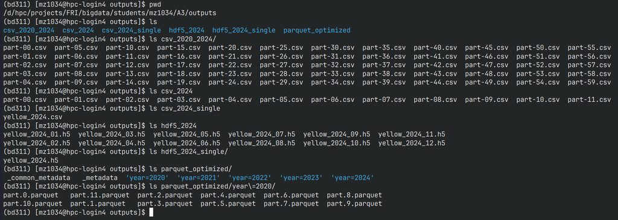

## Comparing data sizes in different formats

To help us better understand differences between the formats and their sizes, we used this small script, `check_output.py`, where we checked the number of files and total size of them, and then also the average, minimum and maximum size of the files in each format.

```
import os

base = "/d/hpc/projects/FRI/bigdata/students/mz1034/A3/outputs"

paths = {
    "CSV 5y": os.path.join(base, "csv_2020_2024"),
    "CSV 2024 (partitioned)": os.path.join(base, "csv_2024"),
    "CSV 2024 (single file)": os.path.join(base, "csv_2024_single"),
    "HDF5 2024 (monthly)": os.path.join(base, "hdf5_2024"),
    "HDF5 2024 (single file)": os.path.join(base, "hdf5_2024_single"),
    "Parquet optimized": os.path.join(base, "parquet_optimized"),
}


def get_all_files(path):
    files = []
    for root, dirs, filenames in os.walk(path):
        for f in filenames:
            full = os.path.join(root, f)
            files.append(full)
    return files


def analyze(path):
    files = get_all_files(path)

    sizes = []
    for f in files:
        size = os.path.getsize(f) / (1024 * 1024)  # MB
        sizes.append(size)

    if len(sizes) == 0:
        return None

    return {
        "count": len(sizes),
        "total": sum(sizes),
        "min": min(sizes),
        "max": max(sizes),
        "avg": sum(sizes) / len(sizes),
    }


print("=" * 20)
print("SIZE ANALYSIS")
print("=" * 20)

for name, path in paths.items():
    print()
    print(name)
    print("-" * 20)

    result = analyze(path)

    if result is None:
        print("No files found")
        continue

    print(f"Files: {result['count']}")
    print(f"Total size (MB): {result['total']:.2f}")
    print(f"Min size (MB): {result['min']:.2f}")
    print(f"Max size (MB): {result['max']:.2f}")
    print(f"Avg size (MB): {result['avg']:.2f}")
```

We obtained the following results:

| Format | Files | Total Size (MB) | Min (MB) | Max (MB) | Avg (MB) |
| --- | --- | --- | --- | --- | --- |
| CSV (2020–2024) | 60 | 18162.16 | 23.89 | 651.20 | 302.70 |
| CSV (2024, partitioned) | 12 | 4286.89 | 310.36 | 399.25 | 357.24 |
| CSV (2024, single file) | 1 | 4286.89 | 4286.89 | 4286.89 | 4286.89 |
| HDF5 (2024, monthly files) | 12 | 6414.57 | 461.90 | 597.40 | 534.55 |
| HDF5 (2024, single file) | 1 | 6412.79 | 6412.79 | 6412.79 | 6412.79 |
| Parquet (optimized) | 62 | 3399.71 | 0.01 | 115.17 | 54.83 |

From this we can see that the optimized parquet format is the smallest by far because of its columnar storage and the used compression. CSV is larger because it stores data in plain text and has no compression in use, meanwhile HDF5 is most likely larger than CSV because of the metadata and the structure overhead (the way it stores data in a hierarchical way). But in general we can see that parquet file is the most efficient format for working with big data.